# Chapter 2- Time Series Graphics

```r
library(fpp3)
```

First, set up your data. Then, plot your graph.

### [2.1 Tsibble Objects](https://otexts.com/fpp3/tsibble-objects.html)

This section contains everything you need to know to set up your data as a time series object.

At a minimum, you need your *y* observations and an index representing time.

Regardless of the package (zoo, xts, etc.) most time series data needs to be explicitly defined as such.

The ffp package uses *tsibbles*, a play on the tidyverses [*tibble*](https://tibble.tidyverse.org/).

```r
y <- tsibble(Year = 2015:2019, Observation = c(123,39,78,52,110), index = Year)
str(y)
```

```
Classes ‘tbl_ts’, ‘tbl_df’, ‘tbl’ and 'data.frame': 5 obs. of  2 variables:
 $ Year       : int  2015 2016 2017 2018 2019
 $ Observation: num  123 39 78 52 110
 - attr(*, "key")=Classes ‘tbl_df’, ‘tbl’ and 'data.frame': 1 obs. of  1 variable:
  ..$ .rows:List of 1
  .. ..$ : int  1 2 3 4 5
 - attr(*, "index")= chr "Year"
  ..- attr(*, "ordered")= logi TRUE
 - attr(*, "index2")= chr "Year"
 - attr(*, "interval")=List of 12
  ..$ year       : num 1
  ..$ quarter    : num 0
  ..$ month      : num 0
  ..$ week       : num 0
  ..$ day        : num 0
  ..$ hour       : num 0
  ..$ minute     : num 0
  ..$ second     : num 0
  ..$ millisecond: num 0
  ..$ microsecond: num 0
  ..$ nanosecond : num 0
  ..$ unit       : num 0
  ..- attr(*, "class")= chr "interval"
```

You can see that the tsibble() function stores the data as a time series object (‘tbl_ts’), is indexed by year (twice, why?) and is on a yearly interval.

```r
z <- tibble(Month = seq(as.Date("2019-01-01"), as.Date("2019-05-01"), by = "1 month"),
            Observation = c(50, 23, 34, 30, 25))
str(z)
```

```
Classes ‘tbl_df’, ‘tbl’ and 'data.frame':   5 obs. of  2 variables:
 $ Month      : Date, format: "2019-01-01" "2019-02-01" "2019-03-01" "2019-04-01" ...
 $ Observation: num  50 23 34 30 25
```

```r
#yes, you can sequence months in R, so cool
z <- z %>%
  mutate(Month = yearmonth(Month)) %>%
  as_tsibble(index = Month)
str(z)
```

```
Classes ‘tbl_ts’, ‘tbl_df’, ‘tbl’ and 'data.frame': 5 obs. of  2 variables:
 $ Month      : yearmonth, format: "2019 Jan" "2019 Feb" "2019 Mar" "2019 Apr" ...
 $ Observation: num  50 23 34 30 25
 - attr(*, "key")=Classes ‘tbl_df’, ‘tbl’ and 'data.frame': 1 obs. of  1 variable:
  ..$ .rows:List of 1
  .. ..$ : int  1 2 3 4 5
 - attr(*, "index")= chr "Month"
  ..- attr(*, "ordered")= logi TRUE
 - attr(*, "index2")= chr "Month"
 - attr(*, "interval")=List of 12
  ..$ year       : num 0
  ..$ quarter    : num 0
  ..$ month      : num 1
  ..$ week       : num 0
  ..$ day        : num 0
  ..$ hour       : num 0
  ..$ minute     : num 0
  ..$ second     : num 0
  ..$ millisecond: num 0
  ..$ microsecond: num 0
  ..$ nanosecond : num 0
  ..$ unit       : num 0
  ..- attr(*, "class")= chr "interval"
```

Getting your time series indexed is the initial up front cost in working with time series data, but it makes analysis workflows much faster. It requires specific knowledge of working with dates and times in R, which is a subject in and of itself. Study up on base R’s date functions, POSIXct objects, or just be a lazy bastard and use [lubridate](https://lubridate.tidyverse.org/).

```r
str(olympic_running)
```

```
Classes ‘tbl_ts’, ‘tbl_df’, ‘tbl’ and 'data.frame': 312 obs. of  4 variables:
 $ Year  : num  1896 1900 1904 1908 1912 ...
 $ Length: Factor w/ 7 levels "100m","200m",..: 1 1 1 1 1 1 1 1 1 1 ...
 $ Sex   : chr  "men" "men" "men" "men" ...
 $ Time  : num  12 11 11 10.8 10.8 NA 10.8 10.6 10.8 10.3 ...
 - attr(*, "key")=Classes ‘tbl_df’, ‘tbl’ and 'data.frame': 14 obs. of  3 variables:
  ..$ Length: Factor w/ 7 levels "100m","200m",..: 1 1 2 2 3 3 4 4 5 5 ...
  ..$ Sex   : chr  "men" "women" "men" "women" ...
  ..$ .rows :List of 14
  .. ..$ : int  1 2 3 4 5 6 7 8 9 10 ...
  .. ..$ : int  32 33 34 35 36 37 38 39 40 41 ...
  .. ..$ : int  55 56 57 58 59 60 61 62 63 64 ...
  .. ..$ : int  85 86 87 88 89 90 91 92 93 94 ...
  .. ..$ : int  103 104 105 106 107 108 109 110 111 112 ...
  .. ..$ : int  134 135 136 137 138 139 140 141 142 143 ...
  .. ..$ : int  148 149 150 151 152 153 154 155 156 157 ...
  .. ..$ : int  179 180 181 182 183 184 185 186 187 188 ...
  .. ..$ : int  202 203 204 205 206 207 208 209 210 211 ...
  .. ..$ : int  233 234 235 236 237 238 239 240 241 242 ...
  .. ..$ : int  245 246 247 248 249 250 251 252 253 254 ...
  .. ..$ : int  272 273 274 275 276 277
  .. ..$ : int  278 279 280 281 282 283 284 285 286 287 ...
  .. ..$ : int  305 306 307 308 309 310 311 312
  ..- attr(*, ".drop")= logi TRUE
 - attr(*, "index")= chr "Year"
  ..- attr(*, "ordered")= logi TRUE
 - attr(*, "index2")= chr "Year"
 - attr(*, "interval")=List of 12
  ..$ year       : int 4
  ..$ quarter    : num 0
  ..$ month      : num 0
  ..$ week       : num 0
  ..$ day        : num 0
  ..$ hour       : num 0
  ..$ minute     : num 0
  ..$ second     : num 0
  ..$ millisecond: num 0
  ..$ microsecond: num 0
  ..$ nanosecond : num 0
  ..$ unit       : num 0
  ..- attr(*, "class")= chr "interval"
```

We can see that the interval on the olympic_running dataset is every 4 years. After the initial list of variables we see that the data is *keyed* with 14 observations of 3 variables, and only **length** and **sex** are listed. So it’s pretty clear that we have our time index, two keys and our response, Time. In other words, the data is laid out in a stacked fashion. Two sexes * seven lengths is 14 observations per year. 312 observations divided by 14 annual observations is 22.285… wait a minute.

```r
table(olympic_running$Year)
```

```
1896 1900 1904 1908 1912 1916 1920 1924 1928 1932 1936 1940 1944 1948 1952 1956 1960 1964 1968 1972 1976 1980 1984 1988 1992 1996 2000 2004 2008
   4    5    5    5    7    7    7    7    9    9    9    9    9   10   10   10   10   11   11   12   12   12   12   13   13   14   14   14   14
2012 2016
  14   14
```

We have different frequencies based on the historical nature of our data.

```r
str(PBS)
```

```
Classes ‘tbl_ts’, ‘tbl_df’, ‘tbl’ and 'data.frame': 65219 obs. of  9 variables:
 $ Month     : yearmonth, format: "1991 Jul" "1991 Aug" "1991 Sep" "1991 Oct" ...
 $ Concession: chr  "Concessional" "Concessional" "Concessional" "Concessional" ...
 $ Type      : chr  "Co-payments" "Co-payments" "Co-payments" "Co-payments" ...
 $ ATC1      : chr  "A" "A" "A" "A" ...
 $ ATC1_desc : chr  "Alimentary tract and metabolism" "Alimentary tract and metabolism" "Alimentary tract and metabolism" "Alimentary tract and metabolism" ...
 $ ATC2      : chr  "A01" "A01" "A01" "A01" ...
 $ ATC2_desc : chr  "STOMATOLOGICAL PREPARATIONS" "STOMATOLOGICAL PREPARATIONS" "STOMATOLOGICAL PREPARATIONS" "STOMATOLOGICAL PREPARATIONS" ...
 $ Scripts   : num  18228 15327 14775 15380 14371 ...
 $ Cost      : num  67877 57011 55020 57222 52120 ...
 - attr(*, "key")=Classes ‘tbl_df’, ‘tbl’ and 'data.frame': 336 obs. of  5 variables:
  ..$ Concession: chr  "Concessional" "Concessional" "Concessional" "Concessional" ...
  ..$ Type      : chr  "Co-payments" "Co-payments" "Co-payments" "Co-payments" ...
  ..$ ATC1      : chr  "A" "A" "A" "A" ...
  ..$ ATC2      : chr  "A01" "A02" "A03" "A04" ...
  ..$ .rows     :List of 336
  .. ..$ : int  1 2 3 4 5 6 7 8 9 10 ...
  .. ..$ : int  205 206 207 208 209 210 211 212 213 214 ...
  .. ..$ : int  409 410 411 412 413 414 415 416 417 418 ...
  .. ..$ : int  613 614 615 616 617 618 619 620 621 622 ...
  .. ..$ : int  817 818 819 820 821 822 823 824 825 826 ...
  .. ..$ : int  913 914 915 916 917 918 919 920 921 922 ...
  .. ..$ : int  1117 1118 1119 1120 1121 1122 1123 1124 1125 1126 ...
  .. ..$ : int  1321 1322 1323 1324 1325 1326 1327 1328 1329 1330 ...
  .. ..$ : int  1525 1526 1527 1528 1529 1530 1531 1532 1533 1534 ...
  .. ..$ : int  1729 1730 1731 1732 1733 1734 1735 1736 1737 1738 ...
  .. ..$ : int  1933 1934 1935 1936 1937 1938 1939 1940 1941 1942 ...
  .. ..$ : int  2137 2138 2139 2140 2141 2142 2143 2144 2145 2146 ...
  .. ..$ : int  2341 2342 2343 2344 2345 2346 2347 2348 2349 2350 ...
  .. ..$ : int  2545 2546 2547 2548 2549 2550 2551 2552 2553 2554 ...
  .. ..$ : int  2749 2750 2751 2752 2753 2754 2755 2756 2757 2758 ...
  .. ..$ : int  2953 2954 2955 2956 2957 2958 2959 2960 2961 2962 ...
  .. ..$ : int  3157 3158 3159 3160 3161 3162 3163 3164 3165 3166 ...
  .. ..$ : int  3361 3362 3363 3364 3365 3366 3367 3368 3369 3370 ...
  .. ..$ : int  3565 3566 3567 3568 3569 3570 3571 3572 3573 3574 ...
  .. ..$ : int  3769 3770 3771 3772 3773 3774 3775 3776 3777 3778 ...
  .. ..$ : int  3973 3974 3975 3976 3977 3978 3979 3980 3981 3982 ...
  .. ..$ : int  4177 4178 4179 4180 4181 4182 4183 4184 4185 4186 ...
  .. ..$ : int  4314 4315 4316 4317 4318 4319 4320 4321 4322 4323 ...
  .. ..$ : int  4518 4519 4520 4521 4522 4523 4524 4525 4526 4527 ...
```

[output cut: 79 more lines]

```
 - attr(*, "index2")= chr "Month"
 - attr(*, "interval")=List of 12
  ..$ year       : num 0
  ..$ quarter    : num 0
  ..$ month      : int 1
  ..$ week       : num 0
  ..$ day        : num 0
  ..$ hour       : num 0
  ..$ minute     : num 0
  ..$ second     : num 0
  ..$ millisecond: num 0
  ..$ microsecond: num 0
  ..$ nanosecond : num 0
  ..$ unit       : num 0
  ..- attr(*, "class")= chr "interval"
```

```r
table(PBS$Month)
```

```
1991 Jul 1991 Aug 1991 Sep 1991 Oct 1991 Nov 1991 Dec 1992 Jan 1992 Feb 1992 Mar 1992 Apr 1992 May 1992 Jun 1992 Jul 1992 Aug 1992 Sep 1992 Oct
     320      320      320      320      320      320      320      320      320      320      320      320      325      325      325      325
1992 Nov 1992 Dec 1993 Jan 1993 Feb 1993 Mar 1993 Apr 1993 May 1993 Jun 1993 Jul 1993 Aug 1993 Sep 1993 Oct 1993 Nov 1993 Dec 1994 Jan 1994 Feb
     325      325      325      325      325      325      325      325      325      325      325      325      325      325      325      325
1994 Mar 1994 Apr 1994 May 1994 Jun 1994 Jul 1994 Aug 1994 Sep 1994 Oct 1994 Nov 1994 Dec 1995 Jan 1995 Feb 1995 Mar 1995 Apr 1995 May 1995 Jun
     325      325      325      325      324      324      324      324      324      324      324      324      324      324      324      324
1995 Jul 1995 Aug 1995 Sep 1995 Oct 1995 Nov 1995 Dec 1996 Jan 1996 Feb 1996 Mar 1996 Apr 1996 May 1996 Jun 1996 Jul 1996 Aug 1996 Sep 1996 Oct
     323      323      323      323      323      323      323      323      323      323      323      323      323      323      323      323
1996 Nov 1996 Dec 1997 Jan 1997 Feb 1997 Mar 1997 Apr 1997 May 1997 Jun 1997 Jul 1997 Aug 1997 Sep 1997 Oct 1997 Nov 1997 Dec 1998 Jan 1998 Feb
     323      323      323      323      323      323      323      323      318      318      318      318      318      318      318      318
1998 Mar 1998 Apr 1998 May 1998 Jun 1998 Jul 1998 Aug 1998 Sep 1998 Oct 1998 Nov 1998 Dec 1999 Jan 1999 Feb 1999 Mar 1999 Apr 1999 May 1999 Jun
     318      318      318      318      310      310      310      310      310      310      310      310      310      310      310      310
1999 Jul 1999 Aug 1999 Sep 1999 Oct 1999 Nov 1999 Dec 2000 Jan 2000 Feb 2000 Mar 2000 Apr 2000 May 2000 Jun 2000 Jul 2000 Aug 2000 Sep 2000 Oct
     307      307      307      307      307      307      307      307      307      307      307      307      309      309      309      309
2000 Nov 2000 Dec 2001 Jan 2001 Feb 2001 Mar 2001 Apr 2001 May 2001 Jun 2001 Jul 2001 Aug 2001 Sep 2001 Oct 2001 Nov 2001 Dec 2002 Jan 2002 Feb
     309      309      309      309      309      309      309      309      307      307      307      307      307      307      307      307
2002 Mar 2002 Apr 2002 May 2002 Jun 2002 Jul 2002 Aug 2002 Sep 2002 Oct 2002 Nov 2002 Dec 2003 Jan 2003 Feb 2003 Mar 2003 Apr 2003 May 2003 Jun
     307      307      307      307      305      305      305      305      305      305      305      305      305      305      305      305
2003 Jul 2003 Aug 2003 Sep 2003 Oct 2003 Nov 2003 Dec 2004 Jan 2004 Feb 2004 Mar 2004 Apr 2004 May 2004 Jun 2004 Jul 2004 Aug 2004 Sep 2004 Oct
     336      336      336      336      336      336      336      336      336      336      336      336      302      302      336      336
2004 Nov 2004 Dec 2005 Jan 2005 Feb 2005 Mar 2005 Apr 2005 May 2005 Jun 2005 Jul 2005 Aug 2005 Sep 2005 Oct 2005 Nov 2005 Dec 2006 Jan 2006 Feb
     336      336      336      336      336      336      336      336      318      318      318      318      318      318      318      318
2006 Mar 2006 Apr 2006 May 2006 Jun 2006 Jul 2006 Aug 2006 Sep 2006 Oct 2006 Nov 2006 Dec 2007 Jan 2007 Feb 2007 Mar 2007 Apr 2007 May 2007 Jun
     318      318      318      318      336      336      336      336      336      336      336      336      336      336      336      336
2007 Jul 2007 Aug 2007 Sep 2007 Oct 2007 Nov 2007 Dec 2008 Jan 2008 Feb 2008 Mar 2008 Apr 2008 May 2008 Jun
     292      295      296      295      293      336      336      336      336      336      336      336
```

We can see that some months have more observations than others.

```r
PBS %>%
  filter(ATC2=="A10") %>%
  select(Month, Concession, Type, Cost)
```

| Month | Concession | Type | Cost |
| --- | --- | --- | --- |
| 1991 Jul | Concessional | Co-payments | 2092878.00 |
| 1991 Aug | Concessional | Co-payments | 1795733.00 |
| 1991 Sep | Concessional | Co-payments | 1777231.00 |
| 1991 Oct | Concessional | Co-payments | 1848507.00 |
| 1991 Nov | Concessional | Co-payments | 1686458.00 |
| 1991 Dec | Concessional | Co-payments | 1843079.00 |
| 1992 Jan | Concessional | Co-payments | 1564702.00 |
| 1992 Feb | Concessional | Co-payments | 1732508.00 |
| 1992 Mar | Concessional | Co-payments | 2046102.00 |
| 1992 Apr | Concessional | Co-payments | 2225977.00 |

[output cut: 806 more lines]

We can perform other dplyr operations on this data, including summarise() and mutate(). The author wants us to save the following subset:

```r
PBS %>%
  filter(ATC2=="A10") %>%
  select(Month, Concession, Type, Cost) %>%
  summarise(TotalC = sum(Cost)) %>%
  mutate(Cost = TotalC/1e6) -> a10
```

The takeaways here are that we want our data to be organized into tsibbles, we want to specify our indexes and keys. Make sure you know the interval of the data.

```r
prison <- readr::read_csv("https://OTexts.com/fpp3/extrafiles/prison_population.csv")
str(prison)
```

```
Classes ‘spec_tbl_df’, ‘tbl_df’, ‘tbl’ and 'data.frame':    3072 obs. of  6 variables:
 $ date      : Date, format: "2005-03-01" "2005-03-01" "2005-03-01" "2005-03-01" ...
 $ state     : chr  "ACT" "ACT" "ACT" "ACT" ...
 $ gender    : chr  "Female" "Female" "Female" "Female" ...
 $ legal     : chr  "Remanded" "Remanded" "Sentenced" "Sentenced" ...
 $ indigenous: chr  "ATSI" "Non-ATSI" "ATSI" "Non-ATSI" ...
 $ count     : num  0 2 0 5 7 58 5 101 51 131 ...
 - attr(*, "spec")=
  .. cols(
  ..   date = col_date(format = ""),
  ..   state = col_character(),
  ..   gender = col_character(),
  ..   legal = col_character(),
  ..   indigenous = col_character(),
  ..   count = col_double()
  .. )
```

```r
table(prison$date) #check interval- data is quarterly
```

```
2005-03-01 2005-06-01 2005-09-01 2005-12-01 2006-03-01 2006-06-01 2006-09-01 2006-12-01 2007-03-01 2007-06-01 2007-09-01 2007-12-01 2008-03-01
        64         64         64         64         64         64         64         64         64         64         64         64         64
2008-06-01 2008-09-01 2008-12-01 2009-03-01 2009-06-01 2009-09-01 2009-12-01 2010-03-01 2010-06-01 2010-09-01 2010-12-01 2011-03-01 2011-06-01
        64         64         64         64         64         64         64         64         64         64         64         64         64
2011-09-01 2011-12-01 2012-03-01 2012-06-01 2012-09-01 2012-12-01 2013-03-01 2013-06-01 2013-09-01 2013-12-01 2014-03-01 2014-06-01 2014-09-01
        64         64         64         64         64         64         64         64         64         64         64         64         64
2014-12-01 2015-03-01 2015-06-01 2015-09-01 2015-12-01 2016-03-01 2016-06-01 2016-09-01 2016-12-01
        64         64         64         64         64         64         64         64         64
```

```r
prison <- prison %>%
  mutate(quarter = yearquarter(date)) %>%
  as_tsibble(key = c(state, gender, legal, indigenous), index = quarter)
str(prison)
```

```
Classes ‘tbl_ts’, ‘tbl_df’, ‘tbl’ and 'data.frame': 3072 obs. of  7 variables:
 $ date      : Date, format: "2005-03-01" "2005-06-01" "2005-09-01" "2005-12-01" ...
 $ state     : chr  "ACT" "ACT" "ACT" "ACT" ...
 $ gender    : chr  "Female" "Female" "Female" "Female" ...
 $ legal     : chr  "Remanded" "Remanded" "Remanded" "Remanded" ...
 $ indigenous: chr  "ATSI" "ATSI" "ATSI" "ATSI" ...
 $ count     : num  0 1 0 0 1 1 1 0 0 1 ...
 $ quarter   : yearquarter, format: "2005 Q1" "2005 Q2" "2005 Q3" "2005 Q4" ...
 - attr(*, "key")=Classes ‘tbl_df’, ‘tbl’ and 'data.frame': 64 obs. of  5 variables:
  ..$ state     : chr  "ACT" "ACT" "ACT" "ACT" ...
  ..$ gender    : chr  "Female" "Female" "Female" "Female" ...
  ..$ legal     : chr  "Remanded" "Remanded" "Sentenced" "Sentenced" ...
  ..$ indigenous: chr  "ATSI" "Non-ATSI" "ATSI" "Non-ATSI" ...
  ..$ .rows     :List of 64
  .. ..$ : int  1 2 3 4 5 6 7 8 9 10 ...
  .. ..$ : int  49 50 51 52 53 54 55 56 57 58 ...
  .. ..$ : int  97 98 99 100 101 102 103 104 105 106 ...
  .. ..$ : int  145 146 147 148 149 150 151 152 153 154 ...
  .. ..$ : int  193 194 195 196 197 198 199 200 201 202 ...
  .. ..$ : int  241 242 243 244 245 246 247 248 249 250 ...
  .. ..$ : int  289 290 291 292 293 294 295 296 297 298 ...
  .. ..$ : int  337 338 339 340 341 342 343 344 345 346 ...
  .. ..$ : int  385 386 387 388 389 390 391 392 393 394 ...
  .. ..$ : int  433 434 435 436 437 438 439 440 441 442 ...
  .. ..$ : int  481 482 483 484 485 486 487 488 489 490 ...
  .. ..$ : int  529 530 531 532 533 534 535 536 537 538 ...
  .. ..$ : int  577 578 579 580 581 582 583 584 585 586 ...
  .. ..$ : int  625 626 627 628 629 630 631 632 633 634 ...
  .. ..$ : int  673 674 675 676 677 678 679 680 681 682 ...
  .. ..$ : int  721 722 723 724 725 726 727 728 729 730 ...
  .. ..$ : int  769 770 771 772 773 774 775 776 777 778 ...
  .. ..$ : int  817 818 819 820 821 822 823 824 825 826 ...
  .. ..$ : int  865 866 867 868 869 870 871 872 873 874 ...
  .. ..$ : int  913 914 915 916 917 918 919 920 921 922 ...
  .. ..$ : int  961 962 963 964 965 966 967 968 969 970 ...
  .. ..$ : int  1009 1010 1011 1012 1013 1014 1015 1016 1017 1018 ...
  .. ..$ : int  1057 1058 1059 1060 1061 1062 1063 1064 1065 1066 ...
  .. ..$ : int  1105 1106 1107 1108 1109 1110 1111 1112 1113 1114 ...
  .. ..$ : int  1153 1154 1155 1156 1157 1158 1159 1160 1161 1162 ...
  .. ..$ : int  1201 1202 1203 1204 1205 1206 1207 1208 1209 1210 ...
```

[output cut: 41 more lines]

```
 - attr(*, "index2")= chr "quarter"
 - attr(*, "interval")=List of 12
  ..$ year       : num 0
  ..$ quarter    : num 1
  ..$ month      : num 0
  ..$ week       : num 0
  ..$ day        : num 0
  ..$ hour       : num 0
  ..$ minute     : num 0
  ..$ second     : num 0
  ..$ millisecond: num 0
  ..$ microsecond: num 0
  ..$ nanosecond : num 0
  ..$ unit       : num 0
  ..- attr(*, "class")= chr "interval"
```

The *periodicity* of the data refers to the number of observations in each cycle. For example, a quarterly cycle has 4 periods. While this might be automatically detected, you should become familiar with the numbers (how many minutes in a year?). “More complicated (and unusual) seasonal patterns can be specified using the [period() function in the lubridate package](https://rawgit.com/rstudio/cheatsheets/master/lubridate.pdf).”

### [2.2 Time Plots](https://otexts.com/fpp3/time-plots.html)

Once you’ve got your tsibble, start with a time plot. Autoplot works.

```r
melsyd_economy <- ansett %>%
  filter(Airports == "MEL-SYD", Class=="Economy")
str(melsyd_economy) #number of passengers flying out of economy from Melbourne to Sydney per week
```

```
Classes ‘tbl_ts’, ‘tbl_df’, ‘tbl’ and 'data.frame': 282 obs. of  4 variables:
 $ Week      : yearweek, format: "1987 W26" "1987 W27" "1987 W28" "1987 W29" ...
 $ Airports  : chr  "MEL-SYD" "MEL-SYD" "MEL-SYD" "MEL-SYD" ...
 $ Class     : chr  "Economy" "Economy" "Economy" "Economy" ...
 $ Passengers: num  20167 20161 19993 20986 20497 ...
 - attr(*, "key")=Classes ‘tbl_df’, ‘tbl’ and 'data.frame': 1 obs. of  3 variables:
  ..$ Airports: chr "MEL-SYD"
  ..$ Class   : chr "Economy"
  ..$ .rows   :List of 1
  .. ..$ : int  1 2 3 4 5 6 7 8 9 10 ...
  ..- attr(*, ".drop")= logi TRUE
 - attr(*, "index")= chr "Week"
  ..- attr(*, "ordered")= logi TRUE
 - attr(*, "index2")= chr "Week"
 - attr(*, "interval")=List of 12
  ..$ year       : num 0
  ..$ quarter    : num 0
  ..$ month      : num 0
  ..$ week       : int 1
  ..$ day        : num 0
  ..$ hour       : num 0
  ..$ minute     : num 0
  ..$ second     : num 0
  ..$ millisecond: num 0
  ..$ microsecond: num 0
  ..$ nanosecond : num 0
  ..$ unit       : num 0
  ..- attr(*, "class")= chr "interval"
```

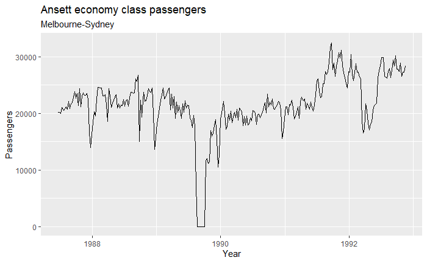

```r
melsyd_economy %>%
  autoplot(Passengers) +
    labs(title = "Ansett economy class passengers", subtitle = "Melbourne-Sydney") +
    xlab("Year")
```

We can see that this uses ggplot and can be modified accordingly.

We can see various “features” of the plot, including a drop to 0 in the late 80’s and a drop in 1992. “Any model will need to take all these features into account in order to effectively forecast the passenger load into the future.”

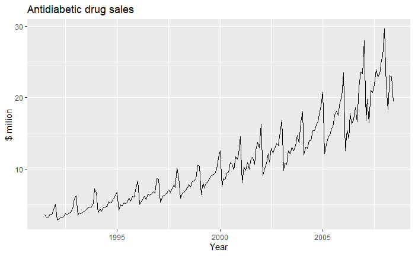

```r
a10 %>% autoplot(Cost) +
  ggtitle("Antidiabetic drug sales") +
  ylab("$ million") + xlab("Year")
```

Using the a10 data (created earlier in the chapter), we can see both the *upward trend* and the seasonal nature of the annual demand. “Any forecasts of this series would need to capture the seasonal pattern, and the fact that the trend is changing slowly.”

### [2.3 Time Series Patterns](https://otexts.com/fpp3/tspatterns.html)

*Trends* are long-term changes over many iterations. They provide the big picture. Trends can change. A *Seasonal* pattern “occurs when a time series is affected by seasonal factors such as the time of the year or the day of the week. Seasonality is always of a fixed and known period.” *Cyclic* patterns are like seasonal patterns except that their changes are not of a fixed frequency, often because the underlying causal mechanisms are complicated. For example, the hiring follows a seasonal pattern but the business cycle is cyclical.

“If the fluctuations are not of a fixed frequency then they are cyclic; if the frequency is unchanging and associated with some aspect of the calendar, then the pattern is seasonal. In general, the average length of cycles is longer than the length of a seasonal pattern, and the magnitudes of cycles tend to be more variable than the magnitudes of seasonal patterns.”

If something appears to be a trend, then zoom out. It may turn out to be a cycle after all.

As always, you need to choose a model that can decompose all three of these features if necessary.

### [2.4 Seasonal Plots](https://otexts.com/fpp3/seasonal-plots.html)

```r
str(a10)
```

```
Classes ‘tbl_ts’, ‘tbl_df’, ‘tbl’ and 'data.frame': 204 obs. of  3 variables:
 $ Month : yearmonth, format: "1991 Jul" "1991 Aug" "1991 Sep" "1991 Oct" ...
 $ TotalC: num  3526591 3180891 3252221 3611003 3565869 ...
 $ Cost  : num  3.53 3.18 3.25 3.61 3.57 ...
 - attr(*, "key")=Classes ‘tbl_df’, ‘tbl’ and 'data.frame': 1 obs. of  1 variable:
  ..$ .rows:List of 1
  .. ..$ : int  1 2 3 4 5 6 7 8 9 10 ...
 - attr(*, "index")= chr "Month"
  ..- attr(*, "ordered")= logi TRUE
 - attr(*, "index2")= chr "Month"
 - attr(*, "interval")=List of 12
  ..$ year       : num 0
  ..$ quarter    : num 0
  ..$ month      : num 1
  ..$ week       : num 0
  ..$ day        : num 0
  ..$ hour       : num 0
  ..$ minute     : num 0
  ..$ second     : num 0
  ..$ millisecond: num 0
  ..$ microsecond: num 0
  ..$ nanosecond : num 0
  ..$ unit       : num 0
  ..- attr(*, "class")= chr "interval"
```

While it may seem untidy at first, one nice feature of the yearmonth key variable format is that it allows you to plot data for different years by month.

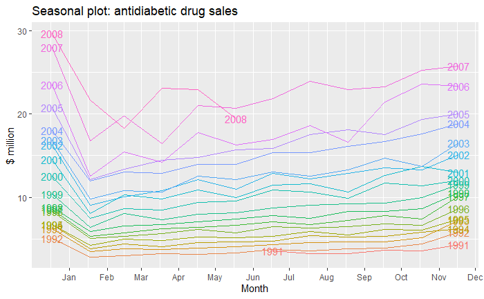

```r
a10 %>% gg_season(Cost, labels = "both") +
  ylab("$ million") +
  ggtitle("Seasonal plot: antidiabetic drug sales")
```

“A seasonal plot allows the underlying seasonal pattern to be seen more clearly, and is especially useful in identifying years in which the pattern changes.”

### [2.5 Seasonal Subseries Plots](https://otexts.com/fpp3/seasonal-subseries-plots.html)

These are just cool.

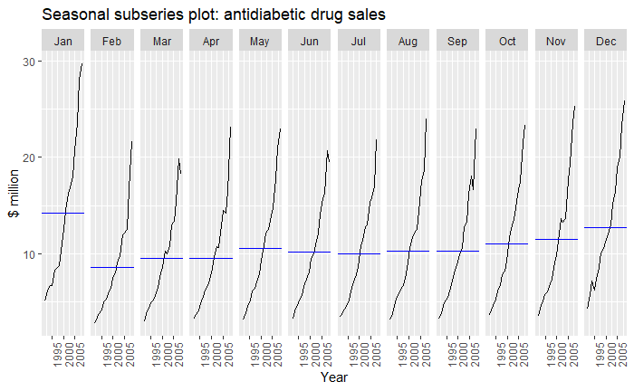

### [2.6 Scatterplots](https://otexts.com/fpp3/scatterplots.html)

When you have two time series that are similar (electricity usage and temperature), you can build a scatterplot. Duh.

You can calculate the correlation, but remember that correlation measures only linear association.

### [2.7 Lag Plots](https://otexts.com/fpp3/lag-plots.html)

Let’s look at the lag in beer production for 1992.

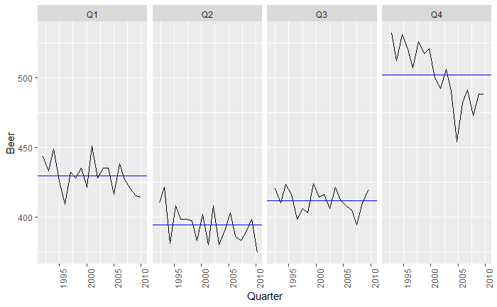

Now lets look at the lag. Note that we’re looking at the lag for each year, that is, each point is a different year.

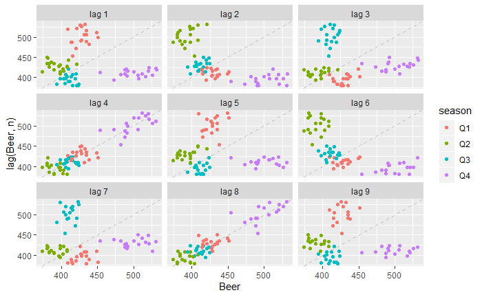

We can see that lag 4 and 8 have strong correlations. Duh, the data is quarterly! We see seasonal variation. At lag 4, beer production is compared to the past year in the same quarter. At lag 8, it’s compared to two years ago.

In lag 2 and 6, we see a strong negative relationship. We’re comparing Q4 to Q2 and Q2 to Q4, which essentially compare the highest and the lowest. See ?gg_lag for more info.

### [2.8 Autocorrelation](https://otexts.com/fpp3/autocorrelation.html)

This has always been an intimidating words… “Just as correlation measures the extent of a linear relationship between two variables, autocorrelation measures the linear relationship between lagged values of a time series.”

See the formulas on the page, but basically we’re looking at the $r_1$ measures the relationship between $y_t$ and $y_{t-1}$, $r_2$ measures the relationship between $y_t$ and $y_{t-2}$, and so forth.

“The autocorrelation coefficients make up the autocorrelation function or ACF.”

```r
recent_production %>% ACF(Beer, lag_max = 9)
```

```
`...` must not be empty for ungrouped data frames.
Did you want `data = everything()`?
```

| lag | acf |
| --- | --- |
| 1Q | -0.10190904 |
| 2Q | -0.65661956 |
| 3Q | -0.06027634 |
| 4Q | 0.86852930 |
| 5Q | -0.08915021 |
| 6Q | -0.63513179 |
| 7Q | -0.05416215 |
| 8Q | 0.83224495 |
| 9Q | -0.10787557 |

“We usually plot the ACF to see how the correlations change with the lag k. The plot is sometimes known as a correlogram.”

Note that we use autoplot() for ACF data.

```
`...` must not be empty for ungrouped data frames.
Did you want `data = everything()`?
```

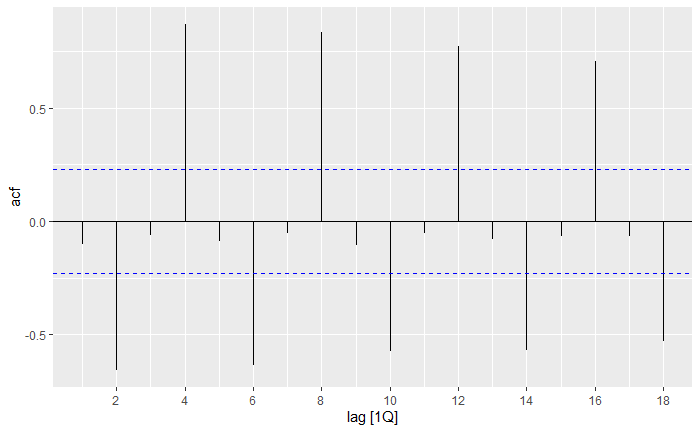

```r
recent_production %>% ACF(Beer) %>% autoplot()
```

Of course, remember that ACF plots measure linear association between lags. Time series data can be transformed: power transforms, differencing, standardization and normalization. Power transforms are covered in chapter 3 and differencing in chapter 9.

```
`...` must not be empty for ungrouped data frames.
Did you want `data = everything()`?
```

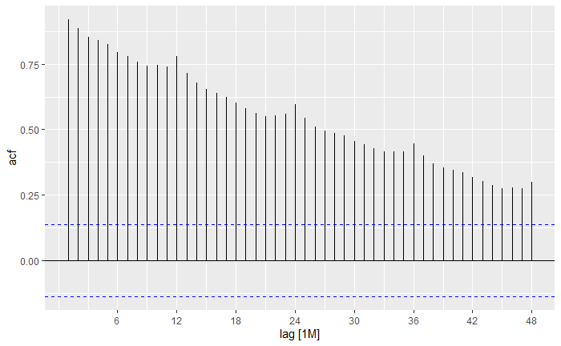

```r
a10 %>% ACF(Cost, lag_max = 48) %>% autoplot()
```

"When data have a trend, the autocorrelations for small lags tend to be large and positive because observations nearby in time are also nearby in size. So the ACF of trended time series tend to have positive values that slowly decrease as the lags increase.

When data are seasonal, the autocorrelations will be larger for the seasonal lags (at multiples of the seasonal frequency) than for other lags.

When data are both trended and seasonal, you see a combination of these effects."

### [2.9 White Noise](https://otexts.com/fpp3/wn.html)

“Time series that show no autocorrelation are called white noise.”

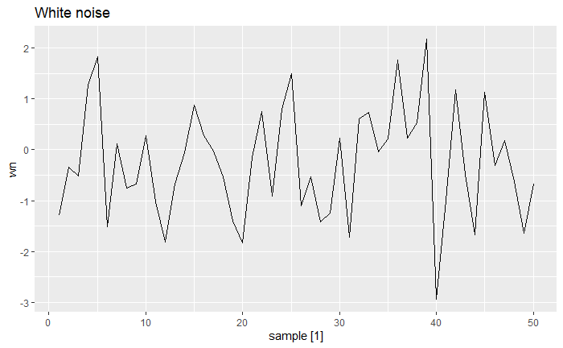

```r
set.seed(30)
y <- tsibble(sample = 1:50, wn = rnorm(50), index = sample)
y %>% autoplot(wn) + ggtitle("White noise")
```

```
`...` must not be empty for ungrouped data frames.
Did you want `data = everything()`?
```

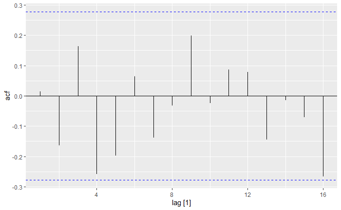

```r
y %>% ACF(wn) %>% autoplot()
```

“For a white noise series, we expect 95% of the spikes in the ACF to lie within ±2/√T where T is the length of the time series.”

In this example, T=50 and so the bounds are at ±2/√50=±0.28. All of the autocorrelation coefficients lie within these limits, confirming that the data are white noise.

I think that this can be tested with Durbin-Watson, but that is not covered here.